# Exploring Data in R

Exploratory Data Analysis (EDA) refers to the critical process of performing initial investigations on data so as to discover patterns,to spot anomalies,to test hypothesis and to check assumptions with the help of summary statistics and graphical representations. In my project, I plan to use the data I cleaned previously to do EDA.

## Dataset Introducation and Plan

### Record dataset about energy consumption by sectors from EIA

The sample source is from U.S. EIA. EIA conducts a comprehensive data collection program that covers the full spectrum of energy sources, end uses, and energy flows; generates short- and long-term domestic and international energy projections; and performs informative energy analyses. EIA disseminates its data products, analyses, reports, and services to customers and stakeholders primarily through its website and the customer contact center.

For the direction I want to study, I need to collect monthly data samples of energy consumption of different groups. Americans use a lot of energy in homes, in businesses, and in industry, and to travel and transport goods.There are three end-use sectors in the dataset that purchase or produce energy for their own consumption and not for resale: - The residential sector includes homes and apartments. - The commercial sector includes offices, malls, stores, schools, hospitals, hotels, warehouses, restaurants, and places of worship and public assembly. - The industrial sector includes facilities and equipment used for manufacturing, agriculture, mining, and construction.

Also the energy type in the dataset is: - Primary energy: Primary energy includes all energy products not transformed, directly exploited or imported. It mainly includes crude oil, oil shale, natural gas, solid mineral fuels, biomass, solar radiation, hydraulic energy, wind energy, geothermic energy and the energy taken from uranium fission. - End-use energy: the energy directly consumed by the user, as opposed to primary energy which is the energy that is harvested directly from natural resources. End use energy includes electricity, gasoline, and natural gas. - Total energy consumption: The summation of all energy consumption in a year

This dataset is useful in understanding the tendency of energy consumption in each sector and in each energy types. After cleaning and tyding the dataset, I can use this predict the future tendency of consumption.

**Load packages and Dataset**

```r
library(selectr)
library(dplyr)
library(ggplot2)
suppressWarnings(expr)#ignore warning
```

```
function (expr)
{
    enexpr(expr)
}
<bytecode: 0x11b47ba50>
<environment: namespace:rlang>
```

```r
options(warn=-1)
library(scales)
library(gridExtra)
```

```r
df <- read.csv("/Users/crystal/Desktop/anly-501-project-HuitingSong/501-project-website/data/cleaned data/clean_sector_v2.csv")
df$Time <- zoo::as.yearmon(paste(df$Year," ",df$Month), "%Y %b")
head(df,5)
```

```
  X   Value    energy_type      sector Year Month     Time
1 1 989.638 Primary Energy Residential 2012   Jan Jan 2012
2 2 830.092 Primary Energy Residential 2012   Feb Feb 2012
3 3 543.901 Primary Energy Residential 2012   Mar Mar 2012
4 4 395.883 Primary Energy Residential 2012   Apr Apr 2012
5 5 267.953 Primary Energy Residential 2012   May May 2012
```

**check the levels of data and change the datatype**

```r
df$energy_type <- as.factor(df$energy_type)
df$sector <- as.factor(df$sector)
str(df)
```

```
'data.frame':   1152 obs. of  7 variables:
 $ X          : int  1 2 3 4 5 6 7 8 9 10 ...
 $ Value      : num  990 830 544 396 268 ...
 $ energy_type: Factor w/ 3 levels "End-Use Energy",..: 2 2 2 2 2 2 2 2 2 2 ...
 $ sector     : Factor w/ 3 levels "Commercial","Industrial",..: 3 3 3 3 3 3 3 3 3 3 ...
 $ Year       : int  2012 2012 2012 2012 2012 2012 2012 2012 2012 2012 ...
 $ Month      : chr  "Jan" "Feb" "Mar" "Apr" ...
 $ Time       : 'yearmon' num  Jan 2012 Feb 2012 Mar 2012 Apr 2012 ...
```

```r
unique(df$sector)
```

```
[1] Residential Commercial  Industrial
Levels: Commercial Industrial Residential
```

```r
unique(df$energy_type)
```

```
[1] Primary Energy End-Use Energy Total
Levels: End-Use Energy Primary Energy Total
```

**Barplot of mean value of consumption in different sectors**

As the graph shown, Industrial sector use contribute a lot in consuming the energy in average. This average consumption makes sense since industrial sector includes facilities and equipment used for manufacturing, agriculture, mining, and construction which are all the place that may use the most energy. The conmercial sector is the least.

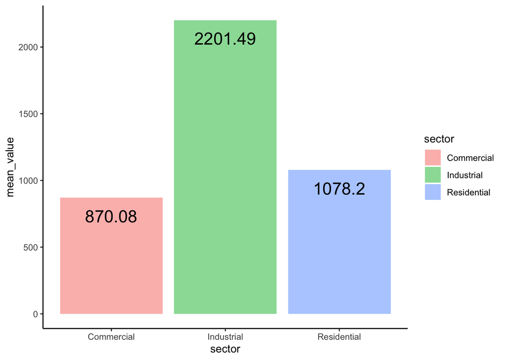

```r
data_histogram <- df %>%
                    group_by(sector) %>%
                    summarize(mean_value = round(mean(Value), 2))

ggplot(data_histogram, aes(x=sector,y = mean_value,fill=sector)) +
    geom_bar(stat = "identity",alpha = 0.5) +
    theme_classic()+
    geom_text(aes(label = mean_value),
        vjust = 2,
        color = "black",
        size = 6)
```

**Barplot of mean value of consumption in different energy type**

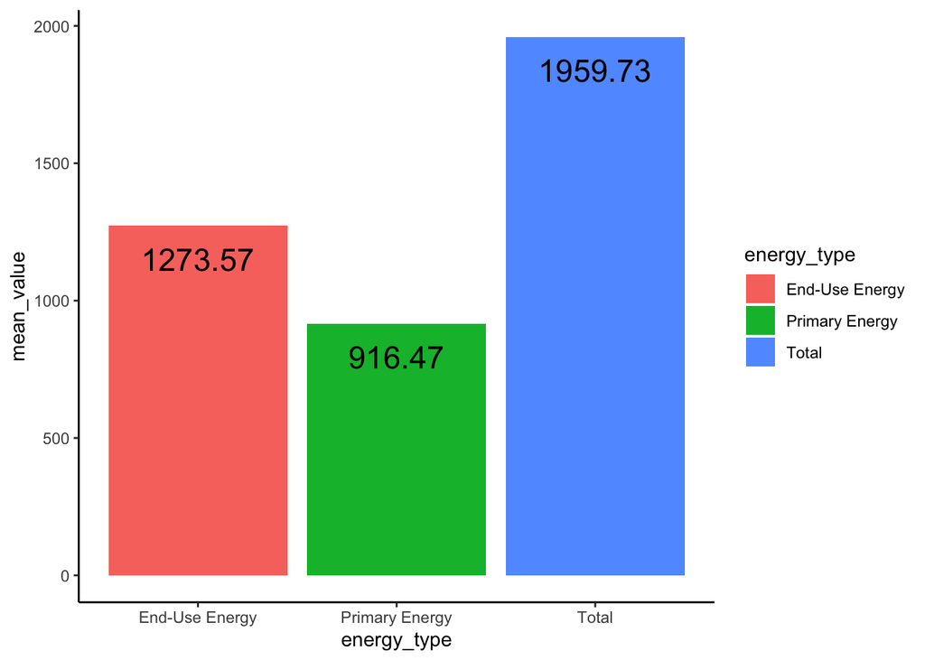

```r
data_histogram <- df %>%
                    group_by(energy_type) %>%
                    summarize(mean_value = round(mean(Value), 2))

ggplot(data_histogram, aes(x=energy_type,y = mean_value,fill=energy_type)) +
    geom_bar(stat = "identity") +
    theme_classic()+
    geom_text(aes(label = mean_value),
        vjust = 2,
        color = "black",
        size = 6)
```

**Line plots**

- in 2022, the energy consumption for each sectors

From the three plots, we can clearly see that The consumption of End-Use energy is always greater than the use of primary energy. However, the consumption tendency of industrial section contradict to other two sectors. For residential and commercial sector, the total energy consumption decreased in the middle of year, but for industrial sector, the total usage increased.

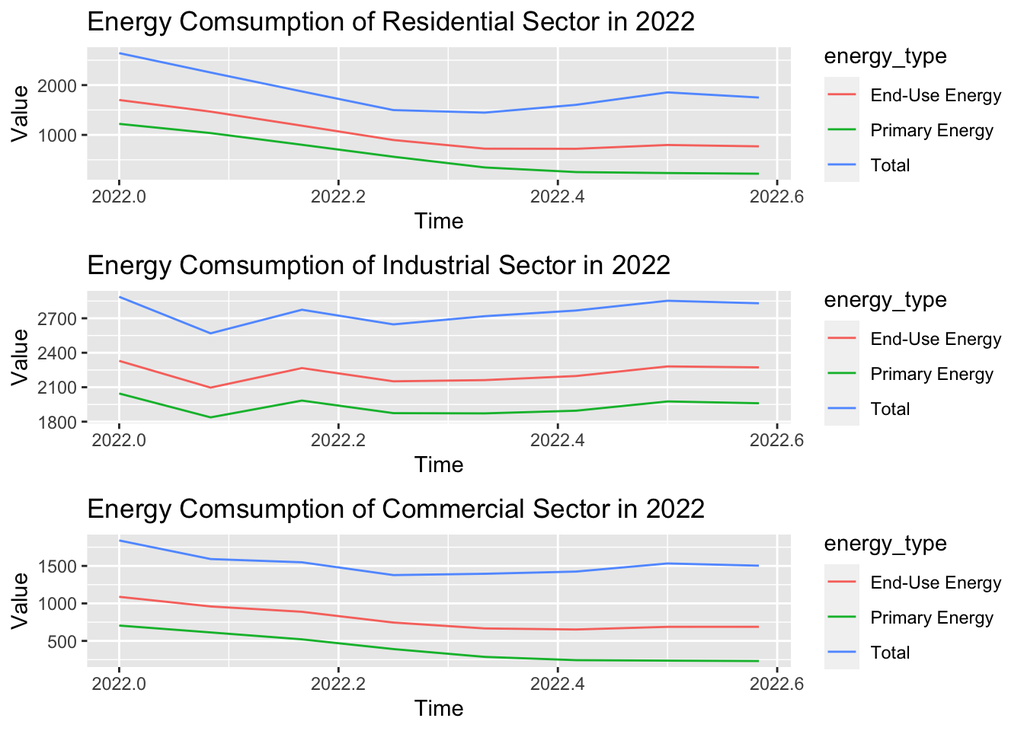

```r
c <- subset(df,df$Year=="2022")
d <- subset(c,c$sector=="Residential")
e <- subset(c,c$sector=="Industrial")
f <- subset(c,c$sector=="Commercial")

plot1 <- ggplot(d, aes(x=Time)) +
            geom_line(aes(y=Value,color=energy_type)) +
            ggtitle("Energy Comsumption of Residential Sector in 2022")
plot2 <- ggplot(e, aes(x=Time)) +
            geom_line(aes(y=Value,color=energy_type)) +
            ggtitle("Energy Comsumption of Industrial Sector in 2022")
plot3 <- ggplot(f, aes(x=Time)) +
            geom_line(aes(y=Value,color=energy_type)) +
            ggtitle("Energy Comsumption of Commercial Sector in 2022")

grid.arrange(plot1, plot2, plot3, ncol=1,nrow=3)
```

- from 2020 to 2022, the energy consumption for each energy

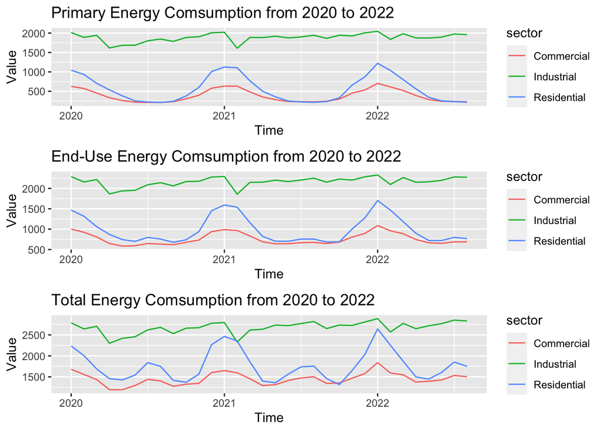

```r
c <- subset(df,df$Year>=2020 & df$Year<=2022)
d <- subset(c,c$energy_type=="Primary Energy")
e <- subset(c,c$energy_type=="End-Use Energy")
f <- subset(c,c$energy_type=="Total")

plot1 <- ggplot(d, aes(x=Time)) +
            geom_line(aes(y=Value,color=sector)) +
            ggtitle("Primary Energy Comsumption from 2020 to 2022")
plot2 <- ggplot(e, aes(x=Time)) +
            geom_line(aes(y=Value,color=sector)) +
            ggtitle("End-Use Energy Comsumption from 2020 to 2022")
plot3 <- ggplot(f, aes(x=Time)) +
            geom_line(aes(y=Value,color=sector)) +
            ggtitle("Total Energy Comsumption from 2020 to 2022")

grid.arrange(plot1, plot2, plot3, ncol=1,nrow=3)
```